# A Tutorial Introduction to R

Aaron A. King, Stu Field, Ben Bolker, Steve Ellner

# How to use this document

These notes contain many sample calculations. It is important to do these yourself—**type them in at your keyboard and see what happens on your screen**—to get the feel of working in **R**.

**Exercises** in the middle of a section should be done immediately when you get to them, and make sure you have them right before moving on.

For your convenience, the **R** codes for this document are provided in a script which you can download, edit, and run.

Many other similar introductions are scattered around the web; a partial list is in the “contributed documentation” section on the R web site (https://cran.r-project.org/other-docs.html). This particular version is limited (it has similar coverage to the standard [*Introduction to* *R* manual](https://cran.r-project.org/doc/manuals/r-release/R-intro.html) and targets biologists who are neither programmers nor statisticians (yet).

Throughout this document, Windows-specific items are marked with a Ⓦ and *nix (linux/unix/MacOSX)-specific items with a Ⓧ.

# What is **R** ?

**R** is a computing environment that combines

- a programming language called **S**, developed by John Chambers at Bell Labs, that implements the idea of *programming with data* (Chambers 1998),
- an extensive set of functions for classical and modern statistical data analysis and modeling,
- powerful numerical analysis tools for linear algebra, differential equations, and stochastics,
- graphics functions for visualizing data and model output,
- a modular and extensible structure that supports a vast array of optional add-on packages, and
- extensive help and documentation facilities.

**R** is an [open source software project](https://en.wikipedia.org/wiki/Open-source_software), available for [free download](https://www.r-project.org/) (R Core Team 2014b). Originally a research project in statistical computing (Ihaka and Gentleman 1996), it is now managed by a development team that includes a number of well-regarded statisticians, and is widely used by statistical researchers and working scientists as a platform for making new methods available to users.

There are a number of graphical front-ends for **R**. At present, the best of these appears to be [**RStudio**](https://www.rstudio.com). Before learning about these, however, you should learn a little about **R** itself.

# Getting started with **R**

## Installing **R** on your computer

The main source for **R** is the [Comprehensive R Archive Network (CRAN)](https://cran.r-project.org). You can get the source code and compile it yourself, but you may prefer at this point to download and install a precompiled version. You can download precompiled binaries for most major platforms from any CRAN mirror. To do so, go to https://cran.r-project.org/mirrors.html and find a mirror site that is geographically somewhat near you. Find the appropriate page for your operating system, and read and follow the installation instructions. **Be sure to install the latest version.**

**R** should work well on any reasonably recent computer.

Ⓦ Under Windows, **R** is installed by launching the downloaded file and following the on-screen instructions. At the end you’ll have an **R** icon on your desktop that can be used to launch the program.

Ⓧ Under Linux, binary versions of **R** are available as packages for the most common Linux distributions. It is also not difficult to install **R** from source.

Ⓧ Under Mac OS X, **R** is available as a binary package.

The standard distributions of **R** include several *packages*: user-contributed suites of add-on functions. These notes use some additional packages which you will have to install before using. Ⓦ In the Windows version additional packages can be installed easily from within **R** using the **Packages** menu. Under all platforms, you can use the commands `install.packages()` and `update.packages()` to install and update packages, respectively. Most packages are available pre-compiled for MacOS X and Windows; under Linux, **R** will download and compile the source code for you.

## Starting **R**

Ⓧ Execute `R` on the command line.

Ⓦ Click on the icon on your desktop, or in the `Start` menu (if you allowed the Setup program to make either or both of these).

## Stopping **R**

> *When entering, always look for the exit.* —Lebanese proverb

Stop **R** by typing `q()` at the command prompt. [Note the `()`: if you type `q` by itself, you will get some confusing output which is actually **R** trying to tell you the definition of the `q` function; more on this later.]

Ⓦ You can also stop **R** from the `File` menu.

When you quit, **R** will ask you if you want to save the workspace (that is, all of the variables you have defined in this session); in general, you should say “no” to avoid clutter and unintentional confusion of results from different sessions. **Note:** When you say “yes” to saving your workspace, it is saved in a hidden file named `.RData`. By default, when you open a new **R** session in the same directory, this workspace is loaded and a message informing you so is printed:

```
[Previously saved workspace restored]
```

Should an **R** command seem to be stuck or take longer than you’re willing to wait, click on the stop sign on the menu bar or hit the `Esc` key (Ⓦ), or `Ctrl-c` (Ⓧ).

# Interactive calculations

Ⓦ When you start **R**, a console window is opened. The console has a few basic menus at the top; check them out on your own.

The console is where you enter commands for **R** to execute *interactively*, meaning that the command is executed and the result is displayed as soon as you hit the `Enter` key. For example, at the command prompt `>`, type in `2+2` and hit `Enter`; you will see

```r
2+2
```

**output**

```
[1] 4
```

The results from calculations can be stored in (*assigned to*) variables. For example:

```r
a <- 2+2
```

**R** automatically creates the variable `a` and stores the result (4) in it, but by default doesn’t print anything. To ask **R** to print the value, just type the variable name by itself

```r
a
```

**output**

```
[1] 4
```

The `[1]` at the beginning of the line is just **R** printing an index of element numbers; if you print a result that displays on multiple lines, **R** will put an index at the beginning of each line. `print(a)` also works to print the value of a variable. By default, a variable created this way is a *vector* (an ordered list), and it is *numeric* because we gave **R** a number rather than (e.g.) a character string like `"pxqr"`; in this case `a` is a numeric vector of length 1;

You could also type

```
a <- 2+2; a
```

using a semicolon to put two or more commands on a single line. Conversely, you can break lines *anywhere that* **R** *can tell you haven’t finished your command* and **R** will give you a “continuation” prompt (`+`) to let you know that it doesn’t think you’re finished yet: try typing

```
a <- 3*(4+
5)
```

to see what happens (this often happens e.g. if you forget to close parentheses or quotes). If you get stuck continuing a command you don’t want—e.g., you opened the wrong parentheses—just hit `Ctrl-c` (Ⓧ), the `Esc` key or the stop icon in the menu bar (Ⓦ) to get out.

You can assign values to variables in **R** using the `<-` operator. There are several alternative forms for assignment. Each of these three commands accomplishes the same thing; the first is the preferred form, however.

```
a <- 2+2
2+2 -> a
a = 2+2
```

Variable names in **R** must begin with a letter, followed by alphanumeric characters. You can break up long names with a period, as in `long.variable.number.3`, an underscore (`very_very_long_variable_name`), or by using camel case (`quiteLongVariableName`); you cannot use blank spaces in variable names. **R** is case sensitive: `Abc` and `abc` are different variables. Good practice is to make variable names long enough to be evocative but short enough to type easily. `N.per.ha` or `pop.density` are better than `x` and `y` (too generic) or `available.nitrogen.per.hectare` (too long).

Note that `c`, `q`, `t`, `C`, `D`, `F`, `I`, and `T`, are built-in **R** functions. Using these are variable names may cause confusion or actual errors.

**R** uses `+`, `-`, `*`, `/`, and `^` for addition, subtraction, multiplication, division and exponentiation, respectively. For example:

```r
x <- 5
y <- 2
z1 <- x*y
z2 <- x/y
z3 <- x^y
z1; z2; z3
```

**output**

```
[1] 10
```

**output**

```
[1] 2.5
```

**output**

```
[1] 25
```

You can retrieve and edit previous commands. The up-arrow ($\uparrow$ ) key or `Ctrl-p` recalls previous commands to the prompt. For example, you can bring back the second-to-last command and edit it to

```r
z3 <- 2*x^y
```

Experiment with the $\downarrow$, $\rightarrow$, $\leftarrow$, `Home` and `End` keys too (also `Ctrl-n`, `Ctrl-b`, `Ctrl-f`, `Ctrl-a`, `Ctrl-e`).

You can combine several operations in one calculation:

```r
A <- 3
C <- (A+2*sqrt(A))/(A+5*sqrt(A)); C
```

**output**

```
[1] 0.5543706
```

Parentheses specify the order of operations. The command

```r
C <- A+2*sqrt(A)/A+5*sqrt(A)
```

is not the same as the one above; rather, it is equivalent to

```r
C <- A + 2*(sqrt(A)/A) + 5*sqrt(A)
```

The default order of operations is: (1) parentheses, (2) exponentiation, (3) multiplication and division, (4) addition and subtraction. Thus:

`> b <- 12-4/2^3` *gives* `12 - 4/8 = 12 - 0.5 = 11.5`  
`> b <- (12-4)/2^3` *gives* `8/8 = 1`  
`> b <- -1^2` *gives* `-(1^2) = -1`  
`> b <- (-1)^2` *gives* `1`

In complicated expressions it’s best to **use parentheses to specify explicitly what you want**, such as `> b <- 12 - (4/(2^3))` or at least `> b <- 12 - 4/(2^3)`; a few extra sets of parentheses never hurt anything.

**R** also has many **built-in mathematical functions** that operate on variables (see below).

##### Exercise

Using keyboard shortcuts wherever you can, use **R** to compute:

1. $\frac{2^7}{2^7 - 1}$
2. $({1 - \frac{1}{2^7}})^{-1}$
3. $1+0.2$
4. $1+0.2+0.2^2/2$
5. $1+0.2+0.2^2/2+0.2^3/6$
6. $e^{0.2}$

Remembering that **R** knows `exp()` but not Euler’s number, $e$, how would you get **R** to tell you the value of $e$?

Compute the standard normal probability density, $\frac{1}{\sqrt{2 \pi}} e^{-x^2/2}$, for values of $x=1$ and $x=2$. [**R** knows $\pi$ as `pi`.] Check your answers against those given by the built-in function for the normal distribution, `dnorm(x=c(1,2))`.

# The help system

**R** has a help system, although it is generally better for reminding you about syntax or details, and for giving cross-references, than for answering basic “how do I …?” questions.

- You can get help on an **R** function named `foo` by entering

```r
?foo
```

or

```r
help(foo)
```

into the console window (e.g., try `?sin`).

- Ⓦ The `Help` menu on the tool bar provides links to other documentation, including the manuals and FAQs, and a search facility (`Apropos` on the menu) which is useful if you half remember part of the name of what it is you need help on.
- Typing `help.start()` opens a web browser with help information.
- `example(cmd)` will run any examples that are included in the help page for command `cmd`.
- `demo(topic)` runs demonstration code on topic `topic`: type `demo()` by itself to list all available demos

By default, **R** ’s help system only provides information about functions that are in the base system and packages that you have already loaded (see below).

- `??topic` or `help.search("topic")` will list information related to `topic` available in the base system or in any extra installed packages: then use `?topic` to see the information, perhaps using `library(pkg)` to load the appropriate package first.
- `help.search` uses fuzzy matching—for example, `help.search("log")` finds more than 800 entries (on my particular system) including lots of functions with “plot”, which includes the letters “lot”, which are *almost* like “log”. If you can’t stand it, you can turn this behavior off with the incantation `help.search("log",agrep=FALSE)` (81 results which still include matches for “logistic”, “myelogenous”, “phylogeny”, ).
- `help(package="pkg")` will list all the help pages for a loaded package.
- `example(fun)` will run the examples (if any) given in the help for a particular function `fun`: e.g., `example(log)`
- `RSiteSearch("topic")` does a full-text search of all the **R** documentation and the mailing list archives for information on `topic` (you need an active internet connection).
- the `sos` package is a web-aware help function that searches all of the packages on CRAN; its `findFn` function tries to find and organize functions in any package on CRAN that match a search string (again, you need a network connection for this).

Try out one or more of these aspects of the help system.

Finally, here’s a commentary on the help system in **R** from Graham Lawrence:

> I hate to say this, but what really helped me the most, after the initial feet-wetting, was to abandon the help manuals. Searching manuals for the answer to a specific question is frustrating because one does not know the key term for the search engine to deliver the item needed.

> So I stopped being serious and production oriented and simply played with **R** for a couple of months. Open the Base package, scan the list of contents for titles that pique my curiosity, paste their examples into **R** and see what happens. And those examples use other functions and their documentation has more examples and so on and on; and pretty soon after, whoops, there’s another afternoon gone down the tubes. But all this apparent time wasting had a most happy result. I now find, much more often than not, that I know what I need to look up to answer a specific question, and that does wonders for my disposition.

> I think of **R** as a vast jungle, criss-crossed with myriad game trails (the documentation to each function in the packages). And I can explore each trail and see what animal it leads to in its native habitat, by pasting the examples into **R** and examining the result. So when I see an interesting spoor or paw print, I take a stroll down that trail and see where it leads. Not the most efficient way of learning the language, no doubt, but a pleasant and interesting entertainment rather than a chore.

##### Exercise

Do an Apropos on `sin` to see what it does. Now enter the command

```r
??sin
```

and see what that does. [Answer: `help.search` pulls up all help pages that include `sin` anywhere in their title or text. Apropos just looks at the name of the function.] Note that `??sin` is equivalent to `help.search("sin")`. If you have a net connection, try `RSiteSearch("sin")` from the command line or the equivalent from the menu and see what happens.

Some of the built-in mathematical functions in **R**.

| **R** command | function |
| --- | --- |
| `abs()` | absolute value, \|x\| |
| `cos()`, `sin()`, `tan()` | cosine, sine, tangent |
| `acos()`, `asin()`, `atan()` | arc-cosine, arc-sine, arc-tangent |
| `exp(x)` | exponential function, $e^x$ |
| `log(x)` | natural (base-$e$) logarithm, $\log{x}=\ln{x}$ |
| `log10(x)` | base-10 logarithm, $\log_{10}{x}$ |
| `sqrt(x)` | square root, $\sqrt{x}$ |
| `atan2(y,x)` | $\arctan(y/x)$ |
| `sum()` | sum of the entries in a vector |
| `diff()` | first differences |
| `cumsum()` | cumulative sum |
| `gamma(x)` | the Gamma function, $\Gamma(x)$ |

You can get a more complete list of functions from the help system: `?Arithmetic` for arithmetic operations, `?log` for logarithmic functions, `?sin` for trigonometric functions, and `?Special` for special functions.

# A first interactive session

## Descriptive statistics

Below are some data on the maximum growth rate $r_{\text{max}}$ of laboratory populations of the green alga *Chlorella vulgaris* as a function of light intensity ($\mu\mathrm{E}~\mathrm{m}^{-2}~\mathrm{s}^{-1}$). These experiments were run during the system-design phase of the study reported by Fussman, Ellner, Sherzer, and Nelson G. Hairston (2000).

| Light: | 20, 20, 20, 20, 21, 24, 44, 60, 90, 94, 101 |
| --- | --- |
| $r_{\text{max}}$: | 1.73, 1.65, 2.02, 1.89, 2.61, 1.36, 2.37, 2.08, 2.69, 2.32, 3.67 |

To analyze these data in **R** , first enter them as numerical *vectors*:

```r
Light <- c(20,20,20,20,21,24,44,60,90,94,101)
rmax <- c(1.73,1.65,2.02,1.89,2.61,1.36,2.37,2.08,2.69,2.32,3.67)
```

The function `c()` *combines* the individual numbers into a vector. Try recalling (with $\uparrow$) and modifying the above command to

```r
Light <- 20,20,20,20,21,24,44,60,90,94,101
```

and see the error message you get: in order to create a vector of specified numbers, you must use the `c()` function.

To see a histogram of the growth rates enter `hist(rmax)`, which opens a graphics window and displays the histogram. There are **many** other built-in statistics functions in **R**. Some of the most commonly used are shown in the table below. Play around with these functions, and any others you can think of.

Some simple descriptive statistics in **R**

| `mean(x)` | the arithmetic mean of the data in `x` |
| --- | --- |
| `exp(mean(log(x)))` | the geometric mean of `x` |
| `1/mean(1/x)` | the harmonic mean of `x` |
| `median(x)` | the median of `x` |
| `min(x)`, `max(x)` | the minimum and maximum, respectively, of `x` |
| `range(x)` | the range of `x` |
| `sd(x)` | the standard deviation of `x` |
| `var(x)` | the variance of `x` |
| `quantile(x, p)` | the `p`-th quantiles of `x` |
| `ecdf(x)` | the empirical cumulative distribution function of `x` |

To see how the algal rate of increase varies with light intensity, type

```r
plot(rmax~Light)
```

**plot**

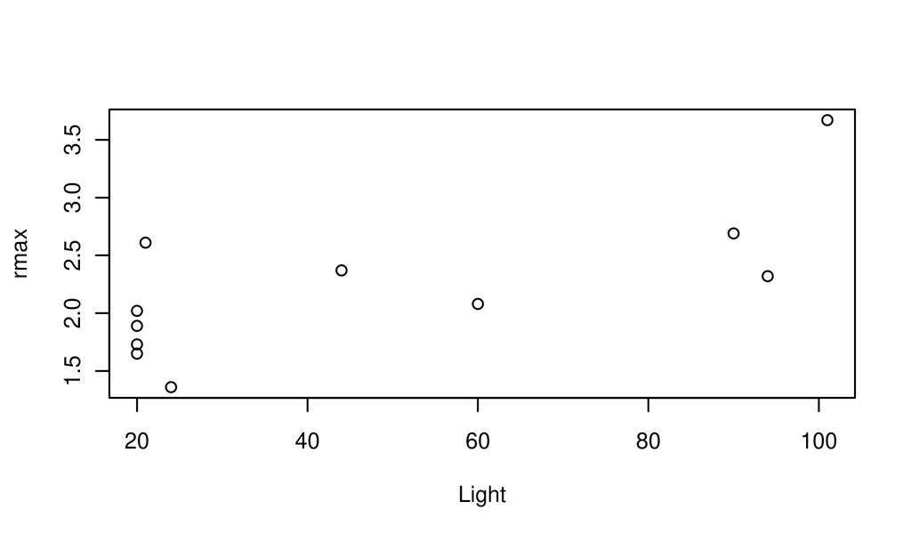

to plot `rmax` ($y$) against `Light` ($x$). You can also do `plot(Light,rmax)`. Based on what you see, does it seem reasonable to hypothesize a linear relationship between these variables?

## Linear regression

To perform linear regression we create a linear model using the `lm()` function:

```r
fit <- lm(rmax~Light)
```

In the formula `rmax~Light`, `rmax` is the response variable and `Light` is the predictor.

The `lm` command created an *object* we have named `fit`. In **R** , an *object* is a data structure consisting of multiple parts. In this case, `fit` holds the results of the linear regression analysis. Unlike other statistics packages, **R** rarely summarizes an analysis for you by default. Statistical analyses in **R** are done by fitting a model to data and then issuing additional commands to extract desired information about the model or display results graphically.

To get a summary of the results, enter the command `summary(fit)`. **R** sets up model objects (more on this later) so that the function `summary()` “knows” that `fit` was created by `lm()`, and produces an appropriate summary of results for an `lm()` object:

```r
summary(fit)
```

**output**

```
Call:
lm(formula = rmax ~ Light)

Residuals:
    Min      1Q  Median      3Q     Max
-0.5478 -0.2607 -0.1166  0.1783  0.7431

Coefficients:
            Estimate Std. Error t value Pr(>|t|)
(Intercept) 1.580952   0.244519   6.466 0.000116 ***
Light       0.013618   0.004317   3.154 0.011654 *
---
Signif. codes:
0 '***' 0.001 '**' 0.01 '*' 0.05 '.' 0.1 ' ' 1

Residual standard error: 0.4583 on 9 degrees of freedom
Multiple R-squared:  0.5251,    Adjusted R-squared:  0.4723
F-statistic: 9.951 on 1 and 9 DF,  p-value: 0.01165
```

If you’ve had a statistics course, the output will make sense to you. The table of coefficients gives the estimated regression line as
$$\text{rmax}=1.58+0.0136\times\text{Light}.$$
Associated with each coefficient is the standard error of the estimate. In addition, for each coefficient, a $t$-test is performed testing the hypothesis that the coefficient differs from zero: the $t$-statistic and the corresponding $p$-values are reported. Finally, the summary reports $R^2$ values and the results of an $F$-test comparing the model to a simple normal null hypothesis.

You can add the regression line to the plot of the data with a function taking `fit` as its input (if you closed the plot of the data, you will need to create it again in order to add the regression line):

```r
abline(fit)
```

[`abline` is a general-purpose function for adding lines to a plot. You can specify horizontal or vertical lines, a slope and an intercept, or a regression model: `?abline`.]

**plot**

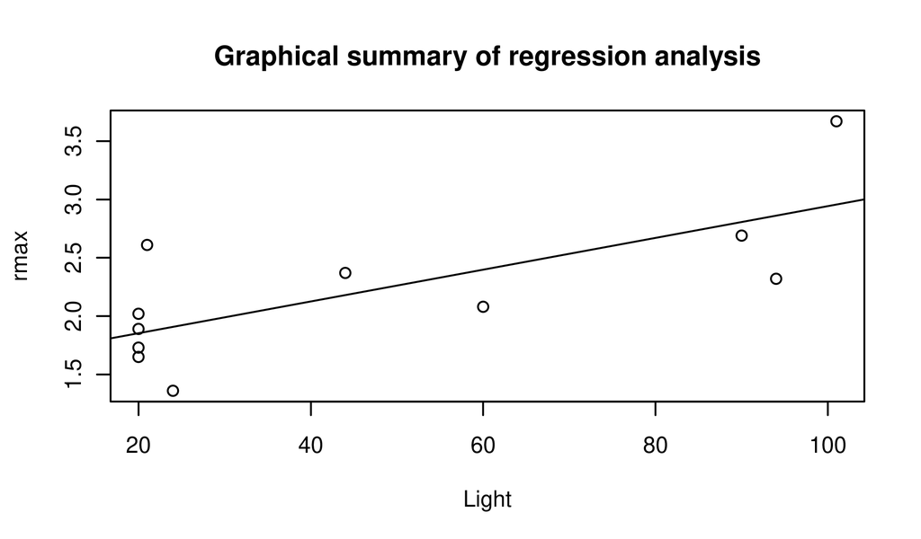

You can extract the coefficients from the fitted model using `coef`:

```r
coef(fit)
```

**output**

```
(Intercept)       Light
 1.58095214  0.01361776
```

There are many other results stored inside `fit`. Try the following:

```r
residuals(fit)
fitted(fit)
effects(fit)
vcov(fit)
anova(fit)
```

# Statistics in **R**

Some of the important functions and packages (collections of functions) for statistical modeling and data analysis are summarized in following table. Functions are named in `fixed-width font` and packages in **bold face**. The book *Modern Applied Statistics with S* (Venables and Ripley 2002) gives a good practical overview, and a list of available packages and their contents can be found at the main **R** website (https://cran.r-project.org, and click on `Packages`).

A few of the functions and packages in **R** for statistical modeling and data analysis are listed below. There are *many* more, but you will have to learn about them somewhere else.

Statistical modeling and data analysis functions and packages.

| `aov`, `anova` | Analysis of variance or deviance |
| --- | --- |
| `lm` | Linear models (regression, ANOVA, ANCOVA) |
| `glm` | Generalized linear models (e.g. logistic, Poisson regression) |
| `gam` | Generalized additive models (in package **mgcv**) |
| `nls` | Nonlinear models via least-squares |
| `lme`, `nlme` | Linear and nonlinear mixed-effects models (repeated measures, block effects, spatial models): in package **nlme** |
| `princomp`, `manova`, `lda`, `cancor` | Multivariate analysis (see also packages **vegan**, **ade4**) |
| **boot** | Package: bootstrapping functions |
| **splines** | Package: nonparametric regression (more in packages **fields**, **KernSmooth**, **logspline**, **sm** and others) |
| **survival** | Package: survival analysis |

# The **R** package system

**R** has many extra packages that provide extra functions. You may be able to install new packages from a menu within **R**. You can always type, e.g.,

```r
install.packages("ggplot2")
```

This installs the **ggplot2** package. You can install more than one package at a time:

```r
install.packages(c("dplyr","tidyr","lubridate"))
```

If the machine on which you use **R** is not connected to the Internet, you can download the packages to some other medium (such as a flash drive or CD) and install them later, using `Install from local zip file` in the menu (Ⓦ) or

```r
install.packages("ggplot2",repos=NULL)
```

If you do not have permission to install packages in **R** ’s central directory, **R** will may ask whether you want to install the packages in a user-specific directory. It is safe to answer “yes” here.

You will frequently get a warning message like

```
Warning message: In file.create(f.tg) :
cannot create file '.../packages.html', reason 'Permission denied'.
```

Don’t worry about this; it means the package has been installed successfully, but the main help system index files couldn’t be updated because of file permissions problems.

# Data structures in **R**

## Vectors

The most basic data-type in **R** is the vector. A vector is just a 1-dimensional array of values. Several different kinds of vectors are available:

- numerical vectors,
- logical vectors,
- character-string vectors,
- factors,
- ordered factors, and
- lists.

Lists are a bit different from the other kinds, so we’ll postpone talking about them until later.

A vector’s defining attributes are its *mode*—which kind of vector it is— and its **length**. Vectors can also have a `names` attribute, which allows one to refer to elements by name.

We’ve already seen how to create vectors in **R** using the `c` function, e.g.,

```r
x <- c(1,3,5,7,9,11)
y <- c(6.5,4.3,9.1,-8.5,0,3.6)
z <- c("dog","cat","dormouse","chinchilla")
w <- c(a=4,b=5.5,c=8.8)
```

```r
length(x)
```

**output**

```
[1] 6
```

```r
mode(y)
```

**output**

```
[1] "numeric"
```

```r
mode(z)
```

**output**

```
[1] "character"
```

```r
names(w)
```

**output**

```
[1] "a" "b" "c"
```

The nice thing about having vectors as a basic type is that many operations in **R** are efficiently *vectorized*. That is, the operation acts on the vector as a unit, saving you the trouble of treating each entry individually. For example:

```r
x <- x+1
xx <- sqrt(x)
x; xx
```

**output**

```
[1]  2  4  6  8 10 12
```

**output**

```
[1] 1.414214 2.000000 2.449490 2.828427 3.162278 3.464102
```

Notice that the operations were applied to every entry in the vector. Similarly, commands like `x-5, 2*x, x/10`, and `x^2` apply subtraction, multiplication, division, and square to each element of the vector. The same is true for operations involving multiple vectors:

```r
x+y
```

**output**

```
[1]  8.5  8.3 15.1 -0.5 10.0 15.6
```

In **R** the default is to apply functions and operations to vectors in an *element by element* manner; anything else (e.g. matrix multiplication) is done using special notation (discussed below).

##### Exercise

What do the `%%` and `%/%` operators do?

### Element recycling

**R** has a very useful, but unusual and perhaps unexpected, behavior when two vector operands in a vectorized operation are of unequal lengths. It will effectively extend the shorter vector using element “re-cycling”: re-using elements of the shorter vector. Thus

```r
x <- c(1,2,3)
y <- c(10,20,30,40,50,60)
x+y
```

**output**

```
[1] 11 22 33 41 52 63
```

```r
y-x
```

**output**

```
[1]  9 18 27 39 48 57
```

##### Exercise

What happens when the length of the longer vector is not a multiple of that of the shorter?

### Functions for creating vectors

A set of regularly spaced values can be created with the `seq` function, whose syntax is `x <- seq(from,to,by)` or `x <- seq(from,to)` or `x <- seq(from,to,length.out)`. The first form generates a vector `(from,from+by,from+2*by,...)` with the last entry not extending further than `to`; in the second form the value of `by` is assumed to be 1 or -1, depending on whether `from` or `to` is larger; and the third form creates a vector with the desired endpoints and length. There is also a shortcut for creating vectors with `by=1`:

```r
1:8
```

**output**

```
[1] 1 2 3 4 5 6 7 8
```

##### Exercise

Use `seq` to create the vector `v=(1 5 9 13)`, and to create a vector going from 1 to 5 in increments of 0.2 .

##### Exercise

What happens when `to` is less than `from` in `seq`? What result does `3:1` give? This is one of the first “gotchas” **R** newbies run into.

A constant vector such as `(1 1 1 1)` can be created with `rep` function, whose basic syntax is `rep(values,lengths)`.  
For example,

```r
rep(3,5)
```

**output**

```
[1] 3 3 3 3 3
```

creates a vector in which the value 3 is repeated 5 times. `rep()` will repeat a whole vector multiple times

```r
rep(1:3,3)
```

**output**

```
[1] 1 2 3 1 2 3 1 2 3
```

or will repeat each of the elements in a vector a given number of times:

```r
rep(1:3,each=3)
```

**output**

```
[1] 1 1 1 2 2 2 3 3 3
```

Even more flexibly, you can repeat each element in the vector a different number of times:

```r
rep(c(3,4),c(2,5))
```

**output**

```
[1] 3 3 4 4 4 4 4
```

The value 3 was repeated 2 times, followed by the value 4 repeated 5 times. `rep()` can be a little bit mind-blowing as you get started, but you’ll get used to it—and it will turn out to be useful.

Some important **R** functions for creating and working with vectors.

| `seq(from,to,by=1)` | Vector of evenly spaced values (default increment = 1) |
| --- | --- |
| `seq(from,to,length.out)` | Vector of evenly spaced values, specified length |
| `c(u,v,...)` | Combine a set of numbers and/or vectors into a single vector |
| `rep(a,b)` | Create vector by repeating elements of `a` `b` times each |
| `hist(v)` | Histogram plot of value in v |
| `mean(v),var(v),sd(v)` | Estimate of population mean, variance, standard deviation based on data values in `v` |
| `cov(v,w)` | Covariance between two vectors |
| `cor(v,w)` | Correlation between two vectors |

Many of these have other optional arguments; use the help system (e.g. `?cor`) for more information. The statistical functions such as `var` regard the values as samples from a population and compute the unbiased estimate of the population statistic; for example `sd(1:3)=1`.

### Vector indexing

It is often necessary to extract a specific entry or other part of a vector. This procedure is called *vector indexing*, and uses square brackets ([]):

```r
z <- c(1,3,5,7,9,11); z[3]
```

**output**

```
[1] 5
```

`z[3]` extracts the third element of the vector `z`. You can also access a block of elements by giving a vector of indices:

```r
v <- z[c(2,3,4,5)]
```

or

```r
v <- z[2:5]; v
```

**output**

```
[1] 3 5 7 9
```

This has extracted the 2nd through 5th elements in the vector.

##### Exercise

If you enter `v <- z[seq(1,5,2)]`, what will happen? Make sure you understand why.

Extracted parts of a vector don’t have to be regularly spaced. For example

```r
v <- z[c(1,2,5)]; v
```

**output**

```
[1] 1 3 9
```

Indexing is also used to **set specific values within a vector**. For example,

```r
z[1] <- 12
```

changes the value of the first entry in `z` while leaving all the rest alone, and

```r
z[c(1,3,5)] <- c(22,33,44)
```

changes the 1st, 3rd, and 5th values.

Elements in a named vector can be accessed and modified by name as well as by position. Thus

```r
w
```

**output**

```
  a   b   c
4.0 5.5 8.8
```

```r
w["a"]
```

**output**

```
a
4
```

```r
w[c("c","b")]
```

**output**

```
  c   b
8.8 5.5
```

```r
w["b"] <- 0
w
```

**output**

```
  a   b   c
4.0 0.0 8.8
```

##### Exercise

Write a *one-line* command to extract a vector consisting of the second, first, and third elements of `z` *in that order*.

##### Exercise

What happens when I set the value of an element that doesn’t exist? For example, try

```r
z[9] <- 11
```

You may be wondering if vectors in **R** are row vectors or column vectors (if you don’t know what those are, don’t worry). The answer is “both and neither”. Vectors are printed out as row vectors, but if you use a vector in an operation that succeeds or fails depending on the vector’s orientation, **R** will assume that you want the operation to succeed and will proceed as if the vector has the necessary orientation. For example, **R** will let you add a vector of length 5 to a $5 \times 1$ matrix or to a $1 \times 5$ matrix, in either case yielding a matrix of the same dimensions.

##### Exercise

Write code that computes values of $y=\frac{(x-1)}{(x+1)}$ for $x=1,2,\cdots,10$, and plots $y$ versus $x$ with the points plotted and connected by a line.

##### Warning: unavoidable imprecision

Note that comparing very similar numeric values can be tricky: rounding can happen, and some numbers cannot be represented exactly on a digital computer. Although **R** *represents* floating point numbers using double precison (64 bits), by default, it only *displays* 7 significant digits. This behavior can be modified with `options("digits")`.

Consider the following three lines of **R** code.

```r
x <- 1.999999; x; x-2
```

**output**

```
[1] 1.999999
```

**output**

```
[1] -1e-06
```

```r
x <- 1.9999999999999; x; x-2
```

**output**

```
[1] 2
```

**output**

```
[1] -9.992007e-14
```

```r
x <- 1.99999999999999999; x; x-2
```

**output**

```
[1] 2
```

**output**

```
[1] 0
```

In the second case, all the digits are still there, but they are not shown, since `x` rounded to 7 decimal places is 2. Also note that `x-2` is not, as it should be, exactly $-1 \times 10^{-13}$; this loss of precision is unavoidable.

What happened in the third case?

##### Exercise

The sum of the geometric series $1 + r + r^2 + r^3 + ... + r^n$ approaches the limit $1/(1-r)$ for $r < 1$ as $n \rightarrow \infty$. Take $r=0.5$ and $n=10$, and write a **one-line** command that creates the vector $G = (r^0,r^1,r^2,...,r^n)$. Compare the sum (using `sum()`) of this vector to the limiting value $1/(1-r)$. Repeat for $n=50$.